# Analysis of fragmented river systems

2026-02-27

## River systems as networks

- River systems can be represented as graphs/networks
- Nodes (vertices) represent river segments
- Links (edges) represent the connections (confluences and barriers) between segments
- Many connectivity indices are defined for graphs, straightforward application to river systems when represented as graphs
- Inclusion of barriers complicates the representation, but several indices can be adapted to account for them (e.g. DCI, Dendritic Connectivity Index)

## The topology of river networks

- Planar networks: no links (edges) intersections
- Tree-like networks: no loops, only one path between any two nodes (vertices)
- Number of nodes (vertices) and links (edges) in a tree-like network: E = V - 1
- Weighted networks: node weights can represent attributes of river segments (e.g. length, discharge, etc.), edge weights can represent the strength of the connection (e.g. presence/absence of a barrier, etc.)

## What we will cover in this presentation

- The `igraph` package for graph manipulation in R
- Processing of geographic data (e.g. HydroRIVERS, HydroBASINS, HydroATLAS datasets) to generate river networks without dams
- processing of geographic data (e.g. AMBER) to generate river networks with dams
- Most of the information is covered already in the [riverconn tutorial](https://damianobaldan.github.io/riverconn_tutorial/)

## Which packages we will use

- `sf` and `terra` for vector and raster data manipulation
- `dplyr` for data manipulation: helps building pipelines for easy-to-read data manipulation (loaded with the `tidyverse`)
- `ggplot2` for data visualization: a bit painful, but easily integrates `sf` and `terra` objects for plotting (loaded with the `tidyverse`)
- `igraph` for graph manipulation: useful for building/editing/managing graphs

## Which packages we will use

```r
library(tidyverse)
library(sf)
library(terra)
library(tidyterra)
library(viridis)
library(igraph)
```

## The `igraph` package

## The `igraph` package

- The `igraph` package implements routines for graphs and network analysis.
- It can handle large graphs very well and provides functions for generating random and regular graphs, graph visualization, centrality methods and much more.
- The packages allows for easy construction of igraph objects based on symbolic description of edges and vertices, edges and vertices lists, or adjacency matrices.
- The book [Statistical Analysis of Network Data with R by Kolaczyk and Csardi (2014)](https://link.springer.com/book/10.1007/978-3-030-44129-6#toc) offers a comprehensive tutorial on the possibilities offered by the igraph package, including network data manipulation and visualization, descriptive analysis of network graphs, mathematical and statistical modeling of graphs, and network topology inference.

## The `igraph` package

We build a graph using a symbolic representation of vertices and edges. The notation 1–2 means that there is an edge between vertices 1 and 2.

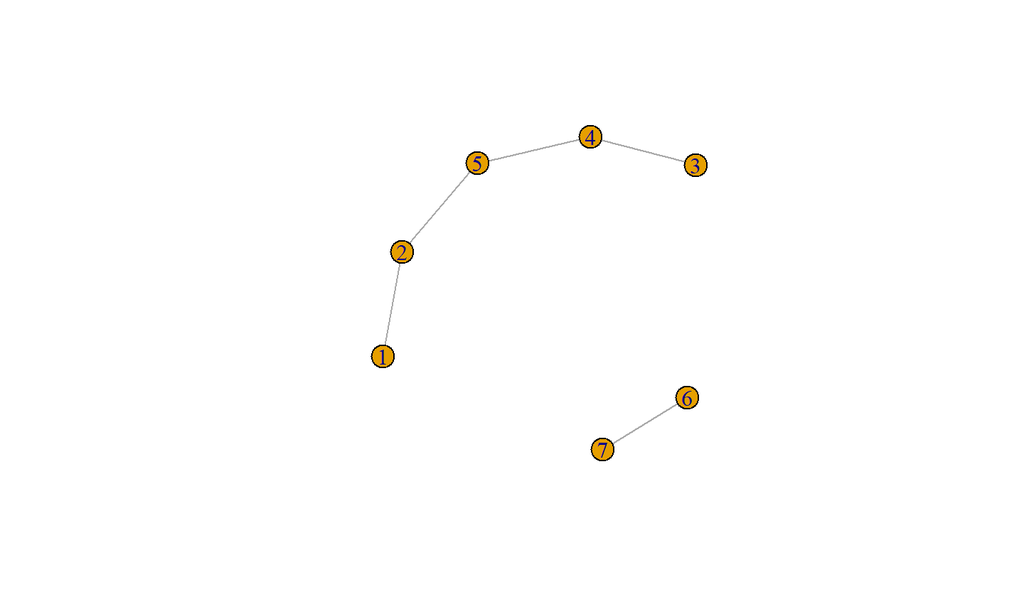

```r
g <- igraph::graph_from_literal(1--2, 2--5, 3--4, 4--5, 6--7)
plot(g)
```

## The `igraph` package

We check the graph. The graph has 7 vertices and 5 edged and is undirected (UN). The graph has the attribute name, that is a vertex attribute of class character. The graph has no edge attributes.

```r
g
```

```
## IGRAPH 4d61056 UN-- 7 5 --
## + attr: name (v/c)
## + edges from 4d61056 (vertex names):
## [1] 1--2 2--5 5--4 3--4 6--7
```

## The `igraph` package

We build a directed graph using a symbolic representation of vertices and edges. The notation 1-+2 means that there is an edge with direction from 1 and 2.

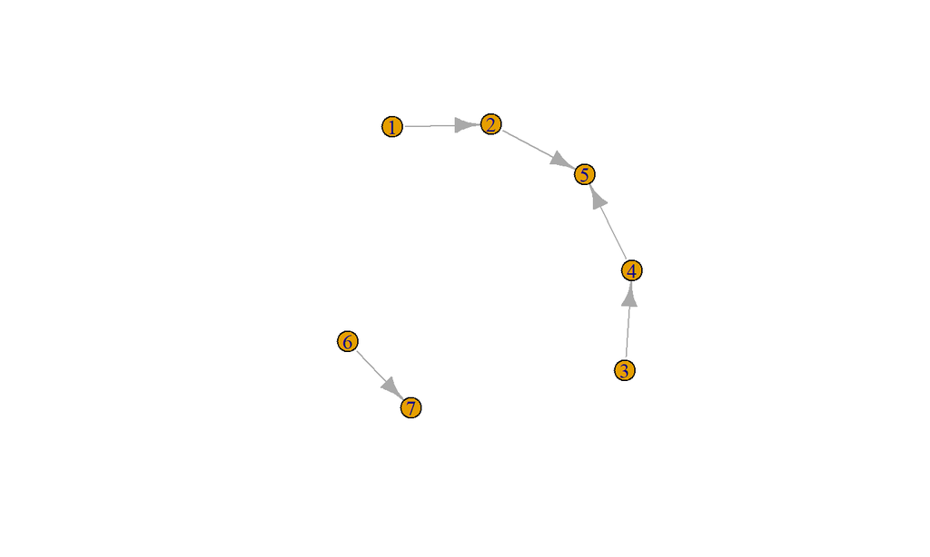

```r
g <- igraph::graph_from_literal(1-+2, 2-+5, 3-+4, 4-+5, 6-+7)
plot(g)
```

## The `igraph` package

We check the graph. The graph has 7 vertices and 5 edged and is directed (DN). The graph has the attribute name, that is a vertex attribute of class character. The graph has no edge attributes.

```r
g
```

```
## IGRAPH 4d6ae8d DN-- 7 5 --
## + attr: name (v/c)
## + edges from 4d6ae8d (vertex names):
## [1] 1->2 2->5 3->4 4->5 6->7
```

## The `igraph` package

We create a graph that is a bit more complex.

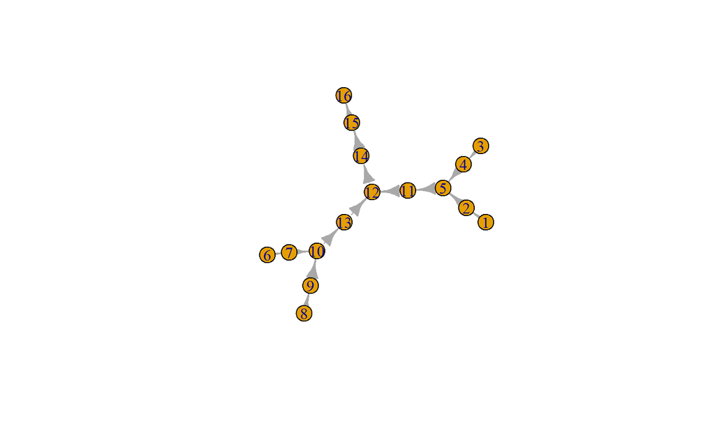

```r
g <- igraph::graph_from_literal( 1-+2, 2-+5, 3-+4, 4-+5, 6-+7,
  7-+10, 8-+9, 9-+10, 5-+11, 11-+12, 10-+13, 13-+12, 12-+14, 14-+15, 15-+16)
plot(g)
```

## The `igraph` package

We can transform this graph to an adjacenty matrix (`as_adjacency_matrix()`; 1 = there is an edge). Note that the matrix is not symmetric because the graph is directed.

```r
mat <- igraph::as_adjacency_matrix(g)
mat[1:8, 1:8]
```

```
## 8 x 8 sparse Matrix of class "dgCMatrix"
##    1 2 5 3 4 6 7 10
## 1  . 1 . . . . .  .
## 2  . . 1 . . . .  .
## 5  . . . . . . .  .
## 3  . . . . 1 . .  .
## 4  . . 1 . . . .  .
## 6  . . . . . . 1  .
## 7  . . . . . . .  1
## 10 . . . . . . .  .
```

## The `igraph` package

The graph can be generated back from the adjacency matrix (`graph_from_adjacency_matrix()`). We check if the new graph is isomorphic (`isomorphic` function) to the original one (i.e. they are the same graph, but with different vertex labels).

```r
g1 <- igraph::graph_from_adjacency_matrix(mat)
igraph::isomorphic(g1, g)
```

```
## [1] TRUE
```

## The `igraph` package

We can transform this graph to a data.frame (`as_data_frame()`). Note that the data.frame has two columns, `from` and `to`, that represent the source and target vertices of each edge.

```r
g_df <- igraph::as_data_frame(g, "edges")
head(g_df)
```

```
##   from to
## 1    1  2
## 2    2  5
## 3    5 11
## 4    3  4
## 5    4  5
## 6    6  7
```

## The `igraph` package

The graph can be generated back from the data.frame (`graph_from_data_frame()`). We check if the new graph is isomorphic (`isomorphic`) to the original one (i.e. they are the same graph, but with different vertex labels).

```r
g1 <- igraph::graph_from_data_frame(g_df)
igraph::isomorphic(g1, g)
```

```
## [1] TRUE
```

## Centrality metrics with the `igraph` package

## Centrality metrics with the `igraph` package

- Centrality metrics are used to identify the most important vertices in a graph
- Identify nodes that are relevant for connecting separate sections of the graph
- Degree centrality: number of edges connected to a vertex (for weighted networks: strenght)
- Betweenness centrality: number of shortest paths that pass through a vertex
- Closeness (harmonic) centrality: inverse of the average shortest path length from a vertex
- For directed and undirected graphs

## Centrality metrics with the `igraph` package

Degree centrality of node \(i\) (\(k_{i}\)): number of edges connected to a vertex (for weighted networks: strenght)

\[k_i = \sum_{j}a_{ij}\] where \(a_{ij}\) is the element of the adjacency matrix that represents the presence (1) or absence (0) of an edge between vertices \(i\) and \(j\)

## Centrality metrics with the `igraph` package

Betweenness centrality: number of shortest paths that pass through a vertex

\[g_i = \sum_{s \neq i \neq t} \frac{\sigma_{st}(i)}{\sigma_{st}} \] where where \(\sigma_{st}\) is the total number of shortest paths from node \(s\) to node \(t\) and \(\sigma_{st}(i)\) is the number of those paths that pass through node \(i\) (not where \(i\) is an end point)

## Centrality metrics with the `igraph` package

Closeness centrality: inverse of the average shortest path length from a vertex

\[c_i = \frac{1}{\sum_{j \neq i} {d(ij)}} \] Harmonic centrality: for disconnected graphs (to avoid issues with \(d(ij) = \infty\))

\[c_i = \sum_{j \neq i} \frac{1}{ {d(ij)}} \]

where \(d(ij)\) is the shortest distance between nodes \(i\) and \(j\)

## Centrality metrics with the `igraph` package

We create a graph, calculate degree, betweeness and closeness centrality and store the values as nodes attributes

```r
g <- igraph::graph_from_literal( 1-+2, 2-+5, 3-+4, 4-+5, 6-+7,
  7-+10, 8-+9, 9-+10, 5-+11, 11-+12, 10-+13, 13-+12, 12-+14, 14-+15, 15-+16)
V(g)$degree <- igraph::degree(g)
V(g)$betweenness <- igraph::betweenness(g)
V(g)$closeness <- igraph::closeness(g, mode = "all")
g
```

```
## IGRAPH 4dc032c DN-- 16 15 --
## + attr: name (v/c), degree (v/n), betweenness (v/n), closeness (v/n)
## + edges from 4dc032c (vertex names):
##  [1] 1 ->2  2 ->5  5 ->11 3 ->4  4 ->5  6 ->7  7 ->10 10->13 8 ->9  9 ->10
## [11] 11->12 12->14 13->12 14->15 15->16
```

## Centrality metrics with the `igraph` package

We plot the graph with vertex color proportional to the centrality metrics

```r
library(ggnetwork)
gg0 <- ggnetwork(g)

pl1 <- ggplot(gg0, aes(x = x, y = y, xend = xend, yend = yend)) +
  geom_edges(arrow = arrow(length = unit(0.5, "lines"), type = "closed")) +
  geom_nodes(aes(color = degree), size = 5) + theme_void()

pl2 <- ggplot(gg0, aes(x = x, y = y, xend = xend, yend = yend)) +
  geom_edges(arrow = arrow(length = unit(0.5, "lines"), type = "closed")) +
  geom_nodes(aes(color = closeness), size = 5) + theme_void()

pl3 <- ggplot(gg0, aes(x = x, y = y, xend = xend, yend = yend)) +
  geom_edges(arrow = arrow(length = unit(0.5, "lines"), type = "closed")) +
  geom_nodes(aes(color = betweenness), size = 5) + theme_void()

plot <- ggpubr::ggarrange(pl1, pl2, pl3, ncol = 3, nrow = 1)
```

## Centrality metrics with the `igraph` package

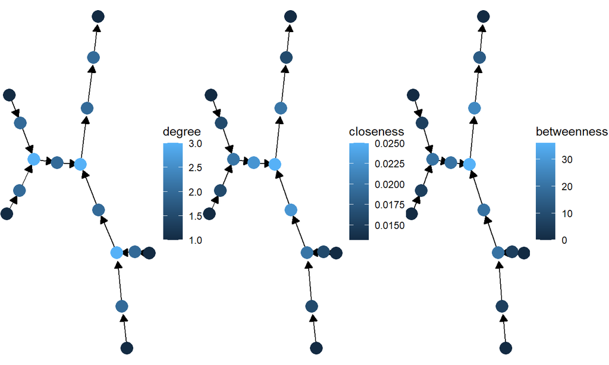

## Generating river graphs from geographic (river) data

## Generating river graphs from geographic (river) data